# Simulation of heterogenous correlation: effects on inference in mixed effects modeling

Vincent J. Carey, stvjc at channing.harvard.edu

September 27, 2024

# 1 Introduction; model

In a certain study of methylation patterns in COPD, longitudinal data on methylation patterns in blood are collected in a complex design. For a fraction of participants, samples from two time points are assayed on a single chip. For the other participants, the samples from the time points are assayed on different chips.

We will use a very simple setup based on bivariate Gaussian responses with different means and correlation coefficients to reflect this design. We assume the two groups of donors are each of size $N$, and that the pairs of observations are obtained at common times denoted 0 and 1.

Donors in group 1 produce samples according to
$$Y_i \sim N_2((0,0)^t, 1, \rho_{11}),$$
using the notation $N_2(\mu, \sigma^2, \rho)$ to denote the bivariate Gaussian distribution with mean vector $\mu$, variance $\sigma^2$ and correlation coefficient $\rho$.

Donors in group 2 produce samples according to
$$Y_i \sim N_2((0,b)^t, 1, \rho_{12}).$$
Both $\rho_{11}$ and $\rho_{12}$ must lie in $[0,1)$.

The parameter of interest is $b$, the difference in mean response between groups 1 and 2 arising from the passage of one unit of time.

# 2 Simulation setup

We will assess various modeling approaches via simulation. We can easily simulate from the models defined above.

We will show that fitting a misspecified model in which the group-specific intrapair correlations are assumed common when in fact they are not leads to a loss of power.

## 2.1 Code

We’ll use MASS to generate multivariate normal deviates, and nlme to fit mixed effects models.

```r
library(MASS)
library(nlme)
```

This function produces the $p$-value for the test of $H_0: b = 0$, using a random intercept with common variance to capture longitudinal dependence.

```r
simdat1 = function(N=100, b=0, r11=.6, r12=.6) {

# set up correlation matrices
 cm1 = matrix(c(1,r11,r11,1),nc=2)
 cm2 = matrix(c(1,r12,r12,1),nc=2)

# simulate residuals
 S1 = as.numeric(t(mvrnorm(N, c(0,0), Sig=cm1)))
 S2 = as.numeric(t(mvrnorm(N, c(0,0), Sig=cm2)))

# set up ID and time variables, and group indicator
 ids = rep(seq_len(2*N),each=2)
 grp = rep(c(0,1),each=2*N)
 time = rep(c(0,1),2*N)

# define responses: S1 has mean 0, S2 has mean b*time
 dat = data.frame(Y=c(S1,S2+b*time[seq_len(2*N)]), id=ids, time=time, grp=grp)
 dat
}

# extract p-value for Ho: b=0
sim1lme = function(dat) {
 mod = lme(Y~time, random=~1|id, data=dat)
 pint = summary(mod)$tTable[2,5]
 list(mod=mod, pint=pint)
}

sim1 = function(N=100, b=0, r11=.6, r12=.6) {
 d = simdat1(N, b, r11, r12)
 sim1lme(d)
}
```

## 2.2 Some sanity checks

This shows that the code captures the $p$-value of interest.

```r
set.seed(123)
f1 = sim1()
summary(f1$mod)
```

```
## Linear mixed-effects model fit by REML
##   Data: dat
##        AIC     BIC    logLik
##   1030.734 1046.68 -511.3672
##
## Random effects:
##  Formula: ~1 | id
##         (Intercept)  Residual
## StdDev:   0.7001695 0.6334928
##
## Fixed effects:  Y ~ time
##                   Value  Std.Error  DF   t-value p-value
## (Intercept)  0.12645227 0.06676640 199  1.893951  0.0597
## time        -0.06429577 0.06334928 199 -1.014941  0.3114
##  Correlation:
##      (Intr)
## time -0.474
##
## Standardized Within-Group Residuals:
##         Min          Q1         Med          Q3         Max
## -2.79966545 -0.52437465  0.01618139  0.49939755  2.06013532
##
## Number of Observations: 400
## Number of Groups: 200
```

```r
f1$pint
```

```
## [1] 0.3113665
```

When $b$ is fixed at zero, the rejection rate based on $p<0.05$ is as expected.

```r
set.seed(123)
library(parallel)
options(mc.cores=6)
```

```r
nn = unlist(mclapply(seq_len(1500), function(x) sim1()$pint))
mean(nn<0.05)
```

```
## [1] 0.052
```

# 3 Power curves for correctly specified and misspecified mixed effects models

For a range of values of $b$, we will plot the rejection frequencies over 1500 realizations of the model with $\rho_{12} = \rho_{11} = 0.6$.

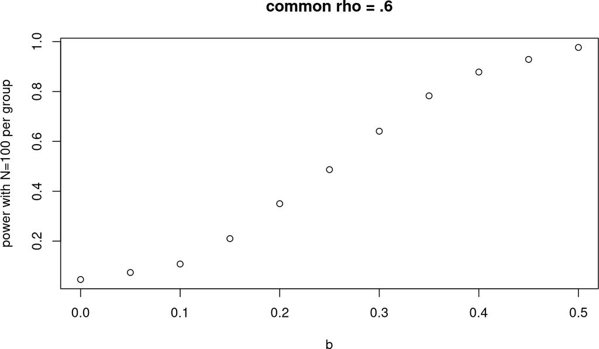

```r
bs = seq(0,.5,.05)
pows_66 = lapply(bs,
 function(b)
   unlist(mclapply(seq_len(1500), function(x) sim1(b=b, r11=.6, r12=.6)$pint))
 )
plot(bs,unlist(sapply(pows_66, function(x) mean(x<0.05))),xlab="b", ylab="power with N=100 per group",
  main = "common rho = .6")
```

Now set $\rho_{12} = 0.2$.

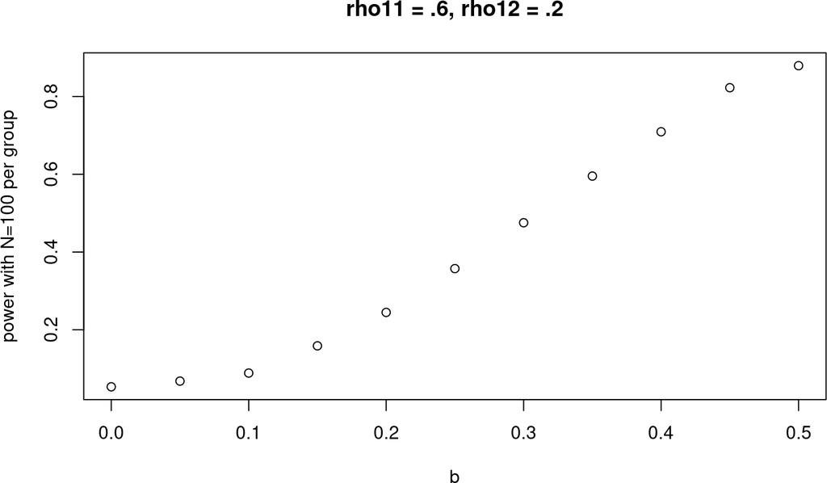

```r
pows_62 = lapply(bs,
 function(b)
   unlist(mclapply(seq_len(1500), function(x) sim1(b=b, r11=.6, r12=.2)$pint))
 )
plot(bs,unlist(sapply(pows_62, function(x) mean(x<0.05))),xlab="b", ylab="power with N=100 per group",
  main = "rho11 = .6, rho12 = .2")
```

Superimposing:

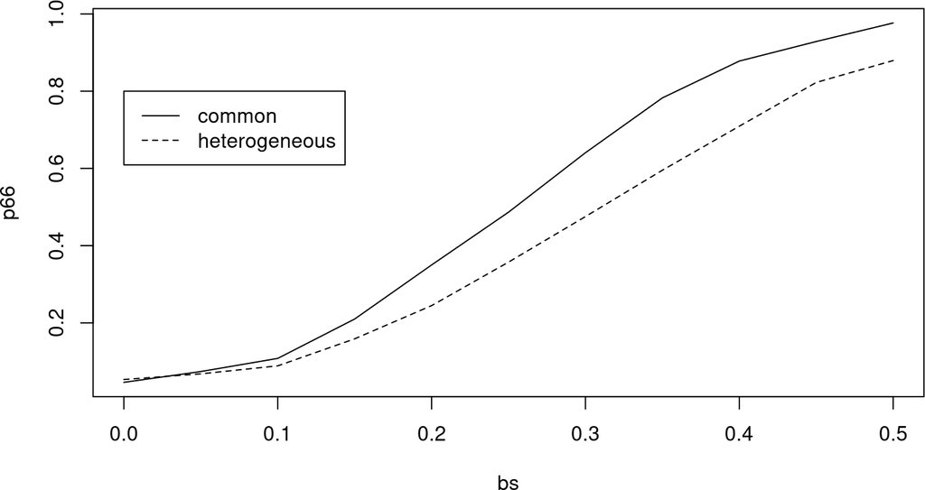

```r
p66 = unlist(sapply(pows_66, function(x) mean(x<0.05)))
p62 = unlist(sapply(pows_62, function(x) mean(x<0.05)))
plot(bs, p66, type="l", lty=1)
lines(bs, p62, lty=2)
legend(0,.8, lty=c(1,2), legend=c("common", "heterogeneous"))
```

# 4 Does adding a dummy variable help restore power?

```r
sim2lme = function(dat) {
 mod = lme(Y~time+grp, random=~1|id, data=dat)
 pint = summary(mod)$tTable[2,5]
 list(mod=mod, pint=pint)
}
sim2 = function(N=100, b=0, r11=.6, r12=.6) {
 d = simdat1(N, b, r11, r12)
 sim2lme(d)
}
# type 1 err
nn = unlist(mclapply(seq_len(1500), function(x) sim2()$pint))
print(mean(nn<0.05))
```

```
## [1] 0.05466667
```

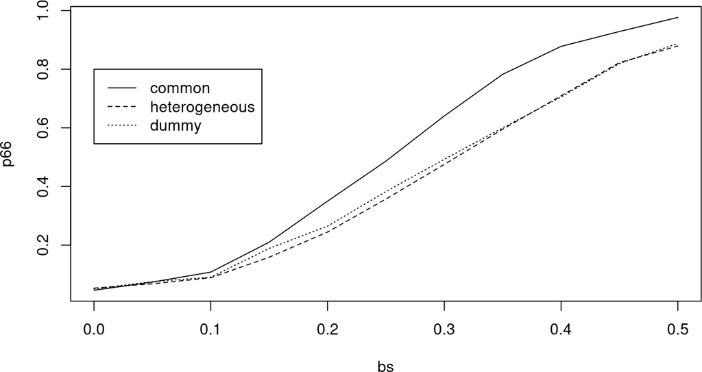

```r
pows_62d = lapply(bs,
 function(b)
   unlist(mclapply(seq_len(1500), function(x) sim2(b=b, r11=.6, r12=.2)$pint))
 )
p62d = unlist(sapply(pows_62d, function(x) mean(x<0.05)))
plot(bs, p66, type="l", lty=1)
lines(bs, p62, lty=2)
lines(bs, p62d, lty=3)
legend(0,.8, lty=c(1,2,3), legend=c("common", "heterogeneous", "dummy"))
```